# mathmodels

Adele

2019/6/2

A document of the lecture “Math Model” in 6/2, 2019.

## Who is fighting who?

### 翻訳の仕事をしていたら

元の原稿：[Rank uncertainty: Why the “most popular” baby names might not be the most popular](https://rss.onlinelibrary.wiley.com/doi/10.1111/j.1740-9713.2017.01037.x)

やってることはこういうこと：

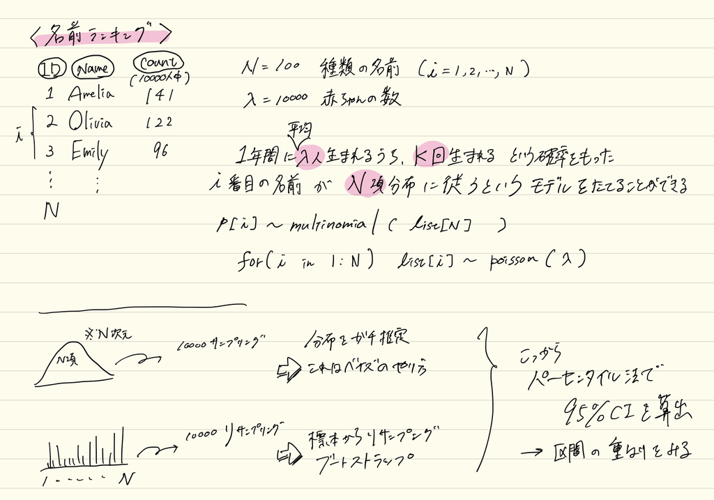

### 気になったこと

- 頻度主義 vs ベイズ主義…vs主義を勝手に考える主義？  
  （最尤推定 vs ベイズ推定と違いますよ！！！）
- 調停役のブートストラップ法
- 戦いの根元には以下の概念のコンセンサスが取れていない現実がある？
  - 無限母集団
  - 超母集団
  - 有限母集団
  - 大標本
  - 標本
  - 小標本
- フィッシャーの「無限母集団仮説」とネイマン―ピアソンの頻度論
- 心理学者を摘発することはできない信頼区間警察
1. 標準化標本の平均値
2. 標準化母集団の平均値
3. 標本から推定した分布（モデル）の平均値
4. 標準正規分布の平均値

- [清水さんの意見](http://norimune.net/3186)（私「”真値”に注目しなくてもよくない？」）
- [フィッシャーからネイマン―ピアソンへのながれ](https://errorstatistics.com/2012/04/16/jerzy-neyman-and-his-enduring-legacy/#more-3399)
- [フィッシャー先生によると：](http://www.stat.purdue.edu/~chen418/study_research/Fisher1921-on%20the%20mathematical%20foundations%20of%20theoretical%20statistics.pdf)

> a hypothetical infinite population, of which the actual data are regarded as constituting a random sample.

…らしいが、どのような母集団分布を考え、どの観測値にどのような確率を充てればいいのかわからなかったところ、ネイマンが「chance mechanism」という、「パラでもノンパラでも観測頻度を確率とすればよい」方法を持ってきたというわけである。まさに観測データ至上主義的発想…。

- 結局、私の意見
  - 「頻度主義」：観測頻度を確率だと思ってモデルを構築する立場
  - 「ベイズ主義」：ベイズの定理によって確率モデルを構築する立場
  - 頻度主義からベイズ主義、それらを包括する統一的方法論の別々の段階、と捉えることもできる
- 統計的漸近理論をやってる[下平さん](https://www.terrapub.co.jp/journals/jjssj/pdf/4102/41020445.pdf)的には、帰無仮説を使えば頻度主義？（ブートストラップはベイズ、という考え方自体珍しいかも）